# Session 02 Business Mathematics Review

[**CCMVI2085U Machine Learning for Predictive Analytics in Business @ CBS ISUP 2020**](https://kursuskatalog.cbs.dk/2019-2020/KAN-CCMVI2085U.aspx?lang=en-GB)

Course coordinator: [Bowei Chen](https://boweichen.github.io/) | Email: bc.acc@cbs.dk

In this session, we are going to have a brief review of mathematical foundations for machine learning and business analytics.

[figure not shown]

# Table of Contents

## Calculus

### Real numbers and real line

Much of calculus is based on properties of the real number system. **Real numbers** are numbers that can be expressed as decimals, such as

$$-\frac{3}{4}=-0.75, \hspace{10pt} \frac{1}{3}=0.33333..., \hspace{10pt} \sqrt{2}=1.1415...$$

The dots $...$ indicate that the sequence of decimal digits goes on forever. Every conceivable decimal expansion represents a real number though some numbers have two representations. Real numbers can be represented geometrically as points on a number line called the **real line**.

The symbol $\mathbb{R}$ denotes either the real number system or, equivalently, the real line.

### Function

A function $f$ is commonly declared by stating its domain $D$ and codomain/range $Y$. We often write $$f:D \rightarrow Y.$$

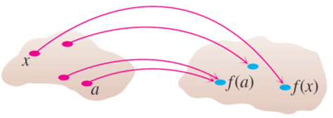

#### Example of functions and their graphs

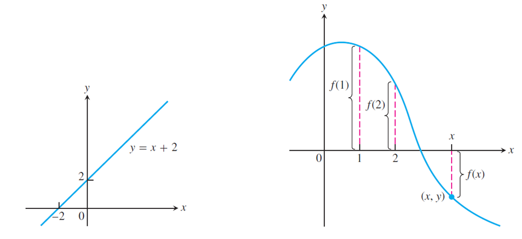

#### Average rate of change over an interval, slope and tangent line

The average rate of change of $y = f(x)$ with respect to $x$ over the interval $[x_1,x_2]$ is

\begin{align*} \frac{\Delta y}{\Delta x} & \ = \frac{f(x_2) - f(x_1)}{x_2 - x_1} = \frac{f(x_1+h) - f(x_1)}{h}, h \neq 0. \end{align*}

The slope of the curve $y = f(x)$ at the point $(x_0, f(x_0))$ is the number

$$ m = \lim_{h \rightarrow 0} \frac{f(x_0+h) - f(x_0)}{h}, $$

and the tangent line to the curve at the point $(x_0, f(x_0))$ is the line through it with this slope.

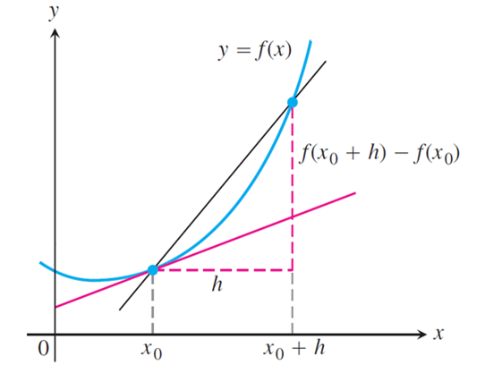

### Derivative

The function $f(x)$ is differentiable at the point $x \in \mathbb{R}$ if the limit $$ \lim_{h \rightarrow 0} \frac{f(x+h) - f(x)}{h} $$ exists, in which case the derivative $f^\prime(x)$ is defined as $$ f^\prime(x) = \lim_{h\rightarrow 0} \frac{f(x+h)-f(x)}{h}. $$ The function $f(x)$ is called differentiable if it is differentiable at all points $x$.

To emphasize the idea that differentiation is an operation performed on a function we sometimes use other notations for the derivative $f^\prime(x)$ such as $\frac{df(x)}{dx}$ or $\frac{d}{dx} f(x)$ or $D_x f(x)$ or $\frac{\partial f(x)}{\partial x}$.

#### Derivative properties and rules

- Linear operator:

$${(f(x) \pm g(x))}^\prime = f^\prime(x) \pm g^\prime(x)$$$${(c f(x))}^\prime = c f^\prime(x)$$

- Product rule:

$$(f(x) g(x))^\prime = f^\prime(x) g(x) + f(x) g^\prime(x)$$

- Quotient rule:

$$\left(\frac{f(x)}{g(x)}\right)^\prime = \frac{f^\prime(x) g(x) - g^\prime(x) f(x)}{(g(x))^2}$$

- Chain rule:

$$(f(g(x)))^\prime = (g \circ f)^\prime (x) =f^\prime(g(x)) g^\prime(x)$$

Here $g \circ f$ denotes function composition $x \mapsto f(x) \mapsto g(f(x))$.

### Taylor series

For a smooth function $f: \mathbb{R} \rightarrow \mathbb{R}$, the Taylor series of $f$ at $x_0$ is defined as $$ T_{\infty}(x) = \sum_{k=0}^{\infty} \frac{f^{(k)}(x_0)}{k!} (x - x_0)^k, $$ where $f^{(k)}(x_0)$ is the $k$th derivative of $f$ at $x_0$ and $\frac{f^{(k)}(x_0)}{k!}$ is the coefficients of the polynomial. For $x_0 = 0$, we obtain the Maclaurin series as a special instance of the Taylor series. If $f(x) = T_{\infty}(x)$, then $f$ is called analytic.

## Linear algebra

### Vectors

An array $\boldsymbol{x}$ of $n$ real numbers $x_1, x_2, \ldots, x_n$ is called a vector, and it is written as $$\boldsymbol{x} = \left[ \begin{array}{c} x_1 \\ x_2 \\ \vdots \\ x_n \\ \end{array} \right] \ \ \ \ \ \text{or} \ \ \ \ \ \boldsymbol{x}^\top = [x_1, x_2, \ldots, x_n], $$ where $\top$ denotes the operation of transposing a column to a row.

Note that:

- Vectors are usually be represented as bold symbols
- A vector $\boldsymbol{x}$ is always a column vector
- A transposed vector $\boldsymbol{x}^\top$ is always a row vector

### Vector arithemetic

- Scalar multiplication

$$a \left[\begin{array}{c} x_1 \\ \vdots \\ x_n \\ \end{array} \right] = \left[\begin{array}{c} a x_1 \\ \vdots \\ a x_n \\ \end{array} \right]$$

- Vector addition $$\left[\begin{array}{c} x_1 \\ \vdots \\ x_n \\ \end{array} \right] + \left[\begin{array}{c} y_1 \\ \vdots \\ y_n \\ \end{array} \right] = \left[\begin{array}{c} x_1 + y_1 \\ \vdots \\ x_n + y_n\\ \end{array} \right]$$
- Vector norm
  - Euclidean norm $$\|\boldsymbol{x}\|_2 = (\sum_{i=1}^n x_i^2)^{1/2} = (\boldsymbol{x}^\top \boldsymbol{x})^{1/2} = \langle\boldsymbol{x}, \boldsymbol{x}\rangle^{1/2}$$
  - $L^p$ norm $$\|\boldsymbol{x}\|_p = (\sum_{i=1}^n x_i^p)^{1/p}$$

### Matrices

A matrix is any rectangular array of real numbers. We denote an arbitrary array of $n$ rows and $p$ columns by $$ \boldsymbol{X} = \left[ \begin{array}{ccc} x_{11} & \cdots & x_{1n} \\ \vdots & \ddots & \vdots \\ x_{n1} & \cdots & x_{mn} \\ \end{array} \right] $$

- Dimension of a matrix is always num rows times num columns
- Matrices will be denoted with bold upper-case letters
- Vectors are special cases of matrices

### Matrices representation of tabular dataset

$$ \begin{array}{rccc} & \text{Age } & \text{Height} & \text{Weight} \\ \text{John} & 32 & 188 & 70 \\ \text{Mary} & 25 & 167 & 50 \\ \vdots & \vdots & \vdots & \vdots \\ \text{Brad} & 18 & 173 & 67 \\ \end{array} $$

The data set can be represented as matrix, where single samples are vectors, e.g.,

$$\text{John: } \boldsymbol{x}_1 = \left[ \begin{array}{c} 32 \\ 188 \\ 70 \\ \end{array} \right] \ \ \ \ \ \text{Mary: } \boldsymbol{x}_2 = \left[ \begin{array}{c} 25 \\ 167 \\ 50 \\ \end{array} \right] $$

Most typical representation:

- Each row represent a data sample (e.g. John)
- Each column represents a data entry (e.g. Age)

$$ \boldsymbol{X} = \left[ \begin{array}{c} \boldsymbol{x}_{1}^\top \\ \vdots \\ \boldsymbol{x}_{n}^\top \\ \end{array} \right] = \left[ \begin{array}{ccc} 32 & 188 & 70 \\ 25 & 167 & 50 \\ \vdots & \ddots & \vdots \\ 18 & 173 & 67 \\ \end{array} \right] $$

### Matrix arithemetic

- Multiplication with scalar
- Addition of matrices
- Matrix transpose
- Matrix-vector product
- Matrix-matrix product

### Types of matrix derivative

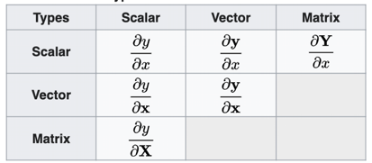

## Probability theory

### Axioms of probability

Consider an experiment (e.g., tossing a die, picking a card from a deck of cards, etc.) whose outcome is not known in advance. Let $S$ denote the sample space of this experiment. A subset $E$ of the sample space is called an event.

A probability measure $\mathbb{P}$ is a function from the set of all events of $S$ to $[0,1]$, which satisfies:

1. $0 = \mathbb{P}(\phi) \leq \mathbb{P}(E) \leq 1.$
2. For all disjoint events $E_1, E_2, E_3, \cdots, E_n$: $\mathbb{P}(E_1 \cup E_2 \cup \cdots \cup E_n) = \sum_{i=1}^{n} \mathbb{P}(E_i).$
3. $\mathbb{P}(S) = 1$

### Random variable

A random variable $X$ is a function with domain $S$ and codomain $\mathbb{R}$ (we can simply write it $X:S \rightarrow \mathbb{R}$).

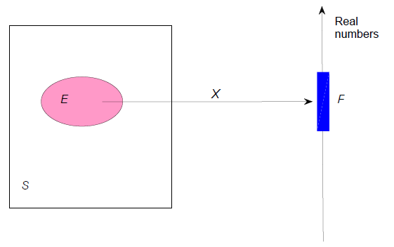

**Example**

Roll 2 dice $S = \{(i,j): i, j = 1, \cdots, 6\}$. Several random variables can be defined. For example, $X = i + j$, and $X$ can take values $2, 3, \cdots, 12$. Also, $Y = |i - j|$, then $Y$ can take values $0, \cdots, 5$.

### Cumulative distribution function

The cumulative distribution function (in short CDF) $F_X: \mathbb{R} \rightarrow [0,1]$ of $X$ is defined by: $$F_X(x) = \mathbb{P}(X \leq x) .$$

Note that:

- Sometimes we simply call CDF the **distribution function**.
- We generally use capital letters to denote random variables and the corresponding lower case letter to denote a realisation (or specific value) of the random variable.
- We can also write $F_X(x) = \mathbb{P}(X \leq x) = \mathbb{P}(\{\omega \in S: X(\omega) \leq x\}).$

### Properties of CDF

- $F_X$ is monotone and non-decreasing, that is: if $a < b$ then $F_X(a) \leq F_X(b)$
- $\lim_{x \rightarrow -\infty} F_X(x) = 0$ and $\lim_{x \rightarrow \infty} F_X(x) = 1$
- $F_X(\cdot)$ is continuous from the right, $\lim_{h \rightarrow 0} F_X (x + h) = F_X(x)$

### Two distinct classes of random variables

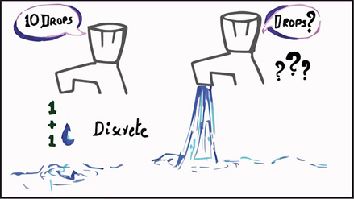

A random variable $X$ is discrete if the range of $X$ is countable, i.e., it has finite or infinitely countable number of possible values. A discrete random variable has the probability mass function (PMF), defined as $$f_X(x_i) = \mathbb{P}(X=x_i), \mbox{ for } i = 1, 2, \cdots $$ We must have that $0 \leq f_X(x_i) \leq 1$ and $\sum_{i}^{} f_X(x_i) = 1$. The CDF can be obtained by $$F_X(x) = \sum_{i: x_i \leq x} \mathbb{P}(X= x_i).$$

A random variable is continuous if it can take on any value in an interval of numbers. A continuous random variable has the \red{probability density function (PDF)}, defined as $$\mathbb{P}(a < X < b) = \int_{a}^{b} f_X(x) dx.$$ We must have that the integral under the $f_X$ curve equals to 1, i.e., $$\mathbb{P}(-\infty < X < \infty) = \int_{-\infty}^{\infty} f_X(x) dy =1.$$

### Expectation & variance of a random variable

Let $X$ be a random variable with range $\mathbb{R}$

The expectation of $X$ is defined by $$\mathbb{E}[X] = \begin{cases} \sum_{i} x_i \mathbb{P}(X=x_i), & \textrm{if } X \textrm{ is discrete},\\ \\ \int_{} x f_X(x) dx, & \textrm{if } X \textrm{ is continuous}. \end{cases} $$

The variance of $X$ is defined by

\begin{align*} \textrm{Var}[X] = & \ \mathbb{E}[(X-\mathbb{E}[X])^2] = \begin{cases} \sum_{i} (x_i - \mathbb{E}[X])^2 \mathbb{P}(X=x_i), & \textrm{if } X \textrm{ is discrete},\\ \\ \int_{} (x - \mathbb{E}[X])^2 f_X(x) dx, & \textrm{if } X \textrm{ is continuous}. \end{cases} \end{align*}

Let $h(X)$ be a function of a random variable $X$. Then $$\mathbb{E}[h(X)] = \begin{cases} \sum_{i} h(x_i) \mathbb{P}(X=x_i), & \textrm{if } X \textrm{ is discrete},\\ \\ \int_{} h(x) f_X(x) dx, & \textrm{if } X \textrm{ is continuous}. \end{cases} $$

### Properties of expectation

- $\mathbb{E}[c] = c$ for a constant $c$.
- $\mathbb{E}[c g(X)] = c \mathbb{E}[g(X)]$ for a constant $c$, where $g(\cdot)$ is a function of $X$.
- $\mathbb{E}[c_1 g_1(X) + c_2 g_2(X)] = c_1 \mathbb{E}[g_1(X)] + c_2 \mathbb{E}[g_2(X)]$ for constants $c_1$ and $c_2$, where $g_1(\cdot)$ and $g_2(\cdot)$ are functions of $X$.
- $\mathbb{E}[g_1(X)] \leq \mathbb{E}[g_2(X)]$ if $g_1(x) \leq g_2(x)$ for all $x$.

### Special univariate distributions

| Discrete distributions | Continuous distributions |
| --- | --- |
| Uniform | Uniform |
| Bernoulli | Normal/Gaussian |
| Binomial | Exponential |
| Geometric |  |
| Poisson |  |

We mainly look at three things for these special distributions:

- How is each specific distribution defined?
- What are the interesting properties or results of a specific distribution?
- In which scenario or type of problems that a specific distribution can be used?

#### Discrete Uniform

The PMF of $X \sim \text{Uniform}(n)$ is given by $$\mathbb{P}(X = x) = \begin{cases} \frac{1}{n} & x = 1, 2, \ldots, n, \\ 0, & \mbox{ otherwise}. \end{cases} $$

$$\mathbb{E}[X] = \frac{n+1}{2}, \ \ \ \ \ \text{Var}(X) = \frac{n^2-1}{12}.$$

If $X \sim \text{Uniform}(n)$, then $\mathbb{E}[X] = \sum_{x=1}^{n} \frac{1}{n} x = \frac{n+1}{2}$, and

\begin{align*} \textrm{Var}(X) = & \ \mathbb{E}[X^2] - \mathbb{E}^2[X]\\ = & \ \sum_{x=1}^{n} \frac{1}{n} x^2 - \left(\frac{n+1}{2} \right)^2\\ = & \ \frac{(2N+1)(n+1)}{6} - \left(\frac{n+1}{2} \right)^2 && \rhd \sum_{x=1}^{n} x^2 = \frac{n(2n+1)(n+1)}{6}\\ = & \ \frac{n^2-1}{12} \end{align*}

**Exercise**

If you roll a fair die and let $X$ be the outcome.

1. What is the probability that the die is 2?
2. What is the probability that the die is less than 3?
3. If you will be given the money as the number the die is shown (e.g., £1 if die is 1) and you can play infinite times of this game, how much money you can expect to earn per game?

**Solution**

1. 1/6
2. 2/6
3. 3.5

#### Bernoulli

The PMF of $X \sim \text{Ber}(p)$ is given by $$\mathbb{P}(X = x) = \begin{cases} p^x (1-p)^{1-x} & x = 0,1, 0 \leq p \leq 1,\\ 0, & \mbox{ otherwise}. \end{cases} $$

$$\mathbb{E}[X] = p, \ \ \ \ \ \ \text{Var}(X) = p (1-p).$$

If $X \sim \text{Ber}(p)$, then $\mathbb{E}[X] = p \times 1 + (1-p) \times 0 = p$, and

\begin{align*} \text{Var}(X) = & \ \mathbb{E}[X^2] - \mathbb{E}^2[X] = p \times 1^2 + (1-p) \times 0^2 - p^2 = p (1-p). \end{align*}

**Exercise**

There is a flipping (fair) coin game. If heads is shown, you can earn £1; if tails is shown, you earn nothing. How much do you think should you be charged to enter the game? What if heads happens with probability 0.4?

**Solution** $$1 \times 0.5 + 0 \times 0.5 = 0.5$$ $$1 \times 0.4 + 0 \times 0.6 = 0.4$$

**Exercise**

An unfair coin is flipped 10 times. For each flipping, heads happens with probability 0.4. What is the probability that exactly 6 heads will occur?

**Solution**

The coin has been flipped independently 10 times, and we are interested in the scenarios that exactly 6 heads occur. For a specific arrangement of coin flipping outcomes, the probability should be $0.4^6 (1-0.4)^4$. There are ${10 \choose 6}$ number of combinations of coin flipping, so we have the ${10 \choose 6} 0.4^6 (1-0.4)^4$.

#### Binomial

The PMF of $X \sim \text{Bin}(n, p)$ is given by $$\mathbb{P}(X = x) = \begin{cases} {n \choose x} p^x (1-p)^{n-x}, & x = 0,1,\cdots,n, \leq p \leq 1,\\ 0, & \mbox{ otherwise}. \end{cases} $$

$$\mathbb{E}[X] = np, \ \ \ \ \ \text{Var}(X) = n p (1-p).$$

If $X \sim \textrm{Bin}(n,p)$, it can be expressed as a sum of $n$ i.i.d. Bernoulli random variables, i.e., $X= \sum_{i=1}^n Y_i$, where $Y_i \sim \text{Ber}(p)$. Then \begin{align*} \mathbb{E}[X] = & \ \mathbb{E}[\sum_{i=1}^n Y_i] = \sum_{i=1}^n \mathbb{E}[Y_i] = np, \\ \mathrm{Var}[X] = & \ \mathrm{Var}[\sum_{i=1}^n Y_i] = \sum_{i=1}^n \mathrm{Var}[Y_i] = np(1-p). \end{align*}

Alternatively, we can compute $\mathbb{E}[X]$ and $\mathrm{Var}[X]$ directly by definition.

\begin{align*} \mathbb{E}[X] = & \ \sum_{k=0}^n {n \choose k} p^k (1-p)^{n-k} k = \sum_{k=1}^n \frac{n!}{(k-1)! (n-k)!} p^k (1-p)^{n-k} \\ = & \ p \sum_{z=0}^{n-1} \frac{n!}{z! (n-(z+1))!} p^z (1-p)^{n-(z+1)} && \rhd z := k-1\\ = & \ p \sum_{z=0}^{m} \frac{(m+1)!}{z! ((m+1)-(z+1))!} p^z (1-p)^{(m+1)-(z+1)} && \rhd m := n-1\\ = & \ (m+1) p \sum_{z=0}^{m} \frac{(m)!}{z! (m-z)!} p^z (1-p)^{m-z} \\ = & \ np, \end{align*}

\begin{align*} \text{Var}[X] = & \ \mathbb{E}[X^2] - \mathbb{E}^2[X] \\ = & \ \sum_{k=0}^n {n \choose k} p^k (1-p)^{n-k} k^2 - n^2 p^2\\ = & \ \sum_{k=0}^n {n \choose k} p^k (1-p)^{n-k} (k(k-1) + k) - n^2 p^2 \\ = & \ \sum_{k=0}^n {n \choose k} p^k (1-p)^{n-k} (k(k-1) + np - n^2 p^2\\ = & \ \sum_{k=2}^n \frac{n!}{(k-2)! (n-k)!} p^k (1-p)^{n-k} + np - n^2 p^2 \\ = & \ p^2 \sum_{z=0}^{n-2} \frac{n!}{z! (n-(z+2))!} p^z (1-p)^{n-(z+2)} + np - n^2 p^2 && \rhd z := k-2\\ = & \ p^2 \sum_{z=0}^{m} \frac{(m+2)!}{z! ((m+2)-(z+2))!} p^z (1-p)^{(m+2)-(z+2)} + np - n^2 p^2 && \rhd m := n-2\\ = & \ (m+2) (m+1) p \sum_{z=0}^{m} \frac{(m)!}{z! (m-z)!} p^z (1-p)^{m-z} + np - n^2 p^2 \\ = & \ n (n-1) p^2 + np - n^2 p^2 = n p (1-p)\\ \end{align*}

**Exercise**

You usually receive 5 text messages per hour. How likely that you will receive:

- Exactly 2 messages in the coming hour?
- 10 or fewer messages in 2 hours?

**Solution**

#### Poisson

The PMF of $X \sim \text{Poi}(\lambda)$ is given by: $$\mathbb{P}(X = x) = \begin{cases} \frac{e^{-\lambda} \lambda^x}{x!} & x = 0, 1, \ldots, \lambda > 0,\\ 0, & \mbox{ otherwise}. \end{cases} $$

$$\mathbb{E}[X] = \lambda, \ \ \ \ \ \text{Var}(X) = \lambda.$$

If $X \sim \textrm{Poi}(\lambda)$, then \begin{align*} \mathbb{E}[X] = & \ \sum_{x=0}^\infty \frac{e^{-\lambda} \lambda^x}{x!} x \\ = & \ \sum_{x=1}^\infty \frac{e^{-\lambda} \lambda^x}{(x-1)!} \\ = & \ \lambda \sum_{z=0}^\infty \frac{e^{-\lambda} \lambda^{z}}{z!} \\ = & \ \lambda && \rhd z := x-1\\ \text{Var}[X] = & \ \mathbb{E}[X^2] - \mathbb{E}^2[X] \\ = & \ \mathbb{E}[X(X-1) + X] - \mathbb{E}^2[X] \\ = & \ \sum_{x=0}^\infty \frac{e^{-\lambda} \lambda^x}{x!} x(x-1) + \lambda - \lambda^2 \\ = & \ \sum_{x=2}^\infty \frac{e^{-\lambda} \lambda^x}{(x-2)!} + \lambda - \lambda^2 \\ = & \ \lambda^2 + \lambda - \lambda^2 = \lambda. \end{align*}

**Poisson approximation of Binomial distribution**

We can consider $n$ is very large and $p$ is very small. Then let $\lambda = n p$. Recall the binomial distribution, the PMF is given by

\begin{align*} f_X(x; n, p) & \ = {n \choose x} p^x (1-p)^{n-x}\\ & \ = \frac{n (n-1) (n-2) \cdots (n-x+1)}{x!} \left(\frac{\lambda}{n}\right)^x \left(1-\frac{\lambda}{n}\right)^{n-x}\\ & \ \approx \frac{\lambda^x}{x!} \left(1 - \frac{\lambda}{n} \right)^n = \frac{\lambda^x}{x!} e^{-\lambda} = f_X(x; \lambda)\\ \end{align*}

#### Geometric

The PMF of $X \sim \text{Geom}(p)$ is given by: $$ \mathbb{P}(X = k) = \begin{cases} (1-p)^{k-1} p & \mbox{ if } k \geq 1, \\ 0, & \mbox{ otherwise}. \end{cases} $$

$$\mathbb{E}[X] = \frac{1}{p}, \ \ \ \ \ \text{Var}(X) = \frac{1}{p^2} - \frac{1}{p}.$$\begin{align*} \mathbb{E}[X] = & \ \sum_{x=1}^\infty p (1-p)^{x-1} x \\ = & \ \sum_{x=1}^\infty p (1-p)^{x-1} (x-1+1)\\ = & \ \sum_{x=1}^\infty p (1-p)^{x-1} (x-1) + \sum_{x=1}^\infty p (1-p)^{x-1}\\ = & \ \sum_{z=0}^\infty p (1-p)^{z} z + 1 && \rhd z := x-1\\ = & \ (1-p) \sum_{z=1}^\infty p (1-p)^{z-1} z + 1 \\ = & \ (1-p) \mathbb{E}[X] + 1, \end{align*}

then $\mathbb{E}[X] = \frac{1}{p}$.

\begin{align*} \mathbb{E}[X^2] = & \ \sum_{x=1}^\infty p (1-p)^{x-1} x^2 \\ = & \ \sum_{x=1}^\infty p (1-p)^{x-1} (x-1+1)^2 \\ = & \ \sum_{x=1}^\infty p (1-p)^{x-1} (x-1)^2 + 2 \sum_{x=1}^\infty p (1-p)^{x-1} (x-1) + \sum_{x=1}^\infty p (1-p)^{x-1} \\ = & \ (1-p) \mathbb{E}[X^2] + 2 (1-p) \mathbb{E}[X] + 1, \end{align*}

then $\mathbb{E}[X^2] = \frac{2-p}{p^2}$. \begin{align*} \text{Var}[X] = & \ \mathbb{E}[X^2] - \mathbb{E}^2[X] = \frac{2-p}{p^2}- \frac{1}{p^2} = \frac{1}{p^2} - \frac{1}{p}. \end{align*}

#### Continuous Uniform

The density of $X \sim \text{Uniform}(a,b)$ is given by $$ f_X(x) = \begin{cases} \frac{1}{b-a} & a \leq x \leq b, \\ 0, & \mbox{ otherwise}. \end{cases} $$

$$\mathbb{E}[X] = \frac{a+b}{2}, \ \ \ \ \ \text{Var}(X) = \frac{(b-a)^2}{12}.$$\begin{align*} \mathbb{E}(X) = & \ \int_a^b \frac{1}{b-a} x dx \\ = & \ \frac{1}{2(b-a)} \int_a^b dx^2 \\ = & \ \frac{a+b}{2}. \\ \text{Var}(X) = & \ \mathbb{E}(X^2) - \mathbb{E}^2(X) \\ = & \ \int_a^b \frac{1}{b-a} x^2 dx - \bigg(\frac{a+b}{2}\bigg)^2 \\ = & \ \frac{1}{3 (b-a)} \int_a^b dx^3 - \bigg(\frac{a+b}{2}\bigg)^2 \\ = & \ \frac{(b-a)^2}{12}. \end{align*}

#### Normal/Gaussian

The density of $X \sim N(\mu,\sigma^2)$ is given by $f_X(x) = \frac{1}{\sqrt{2 \pi \sigma^2}} e^{-\frac{(x-\mu)^2}{2 \sigma^2}} \mbox{ for } x \in \mathbb{R}.$

$$\mathbb{E}[X] = \mu, \ \ \ \ \ \text{Var}(X) = \sigma^2.$$

#### Exponential

$$\mathbb{E}[X] = \frac{1}{\lambda}, \ \ \ \ \ \text{Var}(X) = \frac{1}{\lambda^2}.$$\begin{align*} \mathbb{E}(X) = & \ \int_0^\infty \lambda e^{-\lambda x} x dx \\ = & \ - \int_0^\infty x d e^{-\lambda x} \\ = & \ - \bigg( x e^{-\lambda x} \bigg|_0^\infty - \int_0^\infty e^{-\lambda x} dx \bigg) \\ = & \ \frac{1}{\lambda}. \\ \text{Var}(X) = & \ \mathbb{E}(X^2) - \mathbb{E}^2(X) \\ = & \ \mathbb{E}(X^2) - \frac{1}{\lambda^2} \\ = & \ \int_0^\infty \lambda e^{-\lambda x} x^2 dx - \frac{1}{\lambda^2} \\ = & - \int_0^\infty x^2 d e^{-\lambda x} - \frac{1}{\lambda^2} \\ = & \ - \bigg( x^2 e^{-\lambda x} \bigg|_0^\infty - \int_0^\infty e^{-\lambda x} d x^2 \bigg) - \frac{1}{\lambda^2}\\ = & \ \frac{2}{\lambda} \int_0^\infty \lambda x e^{-\lambda x} d x - \frac{1}{\lambda^2} \\ = & \ \frac{1}{\lambda^2}. \end{align*}

**Exercise**

You usually receive 5 text messages per hour. What is the probability that you will receive your first message in the next hour?

**Solution**

\begin{align*} X & \ = \textrm{the waiting hour for the first message} \\ Y & \ = \textrm{the number of messages received for the next hour} \\ \mathbb{P}(X \leq 1) = & \ 1 - \mathbb{P}(X > 1) = 1 - \mathbb{P}(Y = 0) = 1 - \frac{ e^{-5} 5^0}{0!} = 1 - e^{-5} \end{align*}

\begin{align*} \mathbb{P}(X \leq x) = & \ 1 - \mathbb{P}(X > x) = 1 - \mathbb{P}(Y = 0) = 1 - \frac{ e^{-\lambda} \lambda^0}{0!} = 1 - e^{-\lambda}, \end{align*} then, $$f(x) = \frac{d \mathbb{P}(X=x)}{dx} = \lambda e^{-\lambda x}.$$

##### Memoryless property

Let $X$ be exponentially distributed with parameter $\lambda$. Suppose we know $X > x_1$. What is the probability that $X$ is also greater than some value $x_1 + x_2$? $$ \mathbb{P}(X > x_1 + x_2 \mid X > x_1) = \frac{\mathbb{P}(X > x_1 + x_2 \textrm{ and } X > x_1)}{\mathbb{P}(X > x_1)} $$ If $X > x_1 + x_2$, then $X > x_1$. Therefore $$ \mathbb{P}(X > x_1 + x_2 \mid X > x_1) = \frac{\mathbb{P}(X > x_1 + x_2)}{\mathbb{P}(X > x_1)} = \frac{\lambda e^{-\lambda (x_1 + x_2)}}{\lambda e^{-\lambda x_1}} = \lambda e^{-\lambda x_2} = \mathbb{P}(X > x_2). $$

The memoryless property means that the future is independent of the past!

**Exercise**

If you flip a fair coin 99 times and do not observe a heads. In your 100th flipping, would you bet on heads or tails?

**Solution**

It doesn't matter how many heads you observed because the new flipping is random (with 50\% heads and 50\% tails). This tells why the gambler is wrong!

### Limit theorems

#### Inequalities

##### Markov inequality

If $X$ is a random variable that takes only nonnegative values, then for any $k > 0$, $$\mathbb{P}(X \geq k) \leq \frac{\mathbb{E}[X]}{k}.$$

What does $\mathbb{P}(X \geq k) \leq \frac{\mathbb{E}[X]}{k}$ tell us?

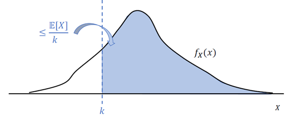

**Exercise**

Let $X$ denote the income of a typical household in Copenhagen. Given that the average income per household is $38,000$, show that no more than 1/5 of the households can earn at least $190,000$.

We need to show that $\mathbb{P}(X \geq 190,000) \leq 1/5$.

**Solution**

We can answer this question using Markov's inequality.

We know that $\mathbb{E}[X] = 38,000$. Define $k = 190,000$. Using Markov's inequality,

$$\mathbb{P}(X \geq 190,000) \leq \frac{38,000}{190,000} = \frac{1}{5}.$$

We can obtain this bound without knowing anything about the specific distribution of $X$ beyond $\mathbb{E}[X]$.

**Proof of Markov inequality**

For $k>0$, let $$ I = \begin{cases} 1, & X \geq k, \\ 0, & \textrm{otherwise}. \end{cases} $$

Since $X \geq 0$, $I \leq \frac{X}{k}$. Taking expectation of the preceding inequality gives $\mathbb{E}[I] \leq \frac{\mathbb{E}[X]}{k}$.

##### Chebyshev's inequality

If $X$ is a random variable with finite mean $\mathbb{E}[X] = \mu$ and variance $\text{Var}[X] = \sigma^2$, then for any value $k > 0$, $$\mathbb{P}(|X-\mu| \geq k) \leq \frac{\sigma^2}{k^2} .$$

**What does $\mathbb{P}(|X-\mu| \geq k) \leq \frac{\sigma^2}{k^2}$ tell us?**

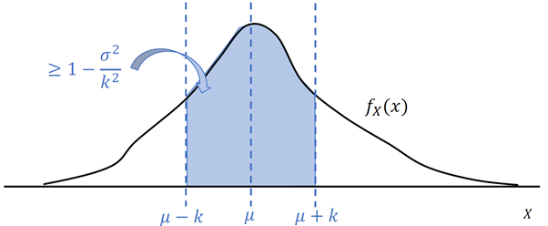

**Exercise**

Suppose that it is known that the number of items produced in a factory during a week is a random variable $X$ with expected value$\mathbb{E}[X] = 50$} and variance $\text{Var}[X] = 25$. Find a lower bound to the probability that this week's production will be between 40 and 60, i.e., $\mathbb{P}(40 < X < 60)$?

**Solution**

By Chebyshev's inequality with $\mathbb{E}[X] = 50$ and $k=10$:

$$\mathbb{P}(|X-50| \geq 10) \leq \frac{\mbox{Var}[X]}{10^2} = \frac{25}{100} = \frac{1}{4}.$$

However, note that $$\mathbb{P}(|X-50| < 10) = \mathbb{P}(40 < X < 60) = 1 - \mathbb{P}(|X-50|\geq 10).$$

Thus, we obtain: $$\mathbb{P}(40 < X < 60) \geq 1 - \frac{1}{4} = \frac{3}{4}.$$

**Proof of Chebyshev's inequality**

Since $(X-\mu)^2 \geq 0$, we can apply Markov's inequality to obtain:

$$\mathbb{P}((X-\mu)^2 \geq k^2) \leq \frac{\mathbb{E}[(X-\mu)^2]}{k^2}. $$

But, since $(X-\mu)^2 \geq k^2$ if and only if $|X-\mu| \geq k$, this is equivalent to:

$$\mathbb{P}(|X-\mu| \geq k) \leq \frac{\mathbb{E}[(X-\mu)^2]}{k^2} = \frac{\sigma^2}{k^2},$$

since $\mathbb{E}[(X-\mu)^2] = Var[X] = \sigma^2$.

##### General version of Chebyshev's inequality

Let $X$ be a random variable with finite mean $\mathbb{E}[X] = \mu$ and variance $\mbox{Var}[X] = \sigma^2$. Let $g(X)$ be a real-valued non-negative function. For any value $k > 0$, then $$\mathbb{P}(g(X) \geq k) \leq \frac{\mathbb{E}[g(X)]}{k} .$$

**Proof of the General version of Chebyshev's inequality**

\begin{align*} \mathbb{E}[g(X)] = & \ \int_{-\infty}^{\infty} g(x) f_X(x) dx \\ = & \ \int_{x:g(x) \geq k} g(x) f_X(x) dx + \int_{x:g(x) < k} g(x) f_X(x) dx\\ \geq & \ \int_{x:g(x) \geq k} g(x) f_X(x) dx \\ \geq & \int_{x:g(x) \geq k} k f_X(x) dx \\ = & \ k \mathbb{P}(g(X) \geq k). \end{align*}

Therefore $$\mathbb{P}(g(X) \geq k) \leq \frac{\mathbb{E}[g(X)]}{k}.$$

#### Law of Large Numbers

The Murphy's Law states that if something can go wrong, then it will. Let's use a fair coin tossing to simply prove this. Consider a fair coin is tossed repeatedly. Show that, with probability one, a head turns up sooner or later.

We consider the probability that no heads ever occurs, then

\begin{align*} \mathbb{P}(\textrm{No heads ever}) = & \ \lim_{n \rightarrow \infty} \mathbb{P}(\textrm{No heads in the first } n \textrm{ tosses}) \\ = & \ \lim_{n \rightarrow \infty} 2^{-n} \\ = & \ 0. \end{align*}

Therefore, $\mathbb{P}(\textrm{A heads occur}) = 1 - \mathbb{P}(\textrm{No heads ever}) = 1$.

Mathematically, we could say: "If there is a nonzero probability that an event will happen in an experiment, then if the experiment is repeated indefinitely the event will eventually happen." Therefore, if we let $p$ be the probability of an event, then if the experiment is repeated indefinitely, the relative frequency of occurrence of the event will approach $p$. This statement is a case of **Law of Large Numbers**.

##### Weak Law of Large Numbers (WLLN)

Let $X_1, X_2, \ldots$ be a sequence of independent and identically distributed random variables, each having finite mean $\mathbb{E}[X_i]=\mu$. Then for any $\epsilon >0$, $$\mathbb{P}\bigg(\Big| \frac{X_1 + \cdots + X_n}{n} - \mu \Big| \geq \epsilon \bigg) \rightarrow 0, \textrm{as } n \rightarrow \infty$$

Let $\bar{X} = \frac{X_1 + \cdots + X_n}{n}$, based on the properties of expectation, we have $$\mathbb{E}[\bar{X}] = \mu, \text{Var}[\bar{X}] = \frac{\sigma^2}{n}.$$

**Simple Proof of WLLN**

We can use the Chebyshev's inequality to obtain \begin{align*} \mathbb{P}\bigg(\Big| \frac{X_1 + \cdots + X_n}{n} - \mu \Big| \geq \epsilon \bigg) \leq & \ \frac{\sigma^2}{n \epsilon^2}. \end{align*}

If $n \rightarrow \infty$, then $\frac{\sigma^2}{n \epsilon^2} \rightarrow 0$.

##### Strong Law of Large Numbers (SLLN)

Let $X_1, X_2, \cdots $ be a sequence of independent and identically distributed random variables having a finite mean $\mu=\mathbb{E}[X_i]$. Then, \emph{almost surely}, $$\bar{X} = \frac{X_1+X_2+\cdots+X_n}{n} \rightarrow \mu, \mbox{ as } n \rightarrow \infty. $$ Alternatively, the SLLN can be expressed as $$\mathbb{P}\Bigg(\lim_{n \rightarrow \infty} \frac{X_1+X_2+\cdots+X_n}{n} = \mu \Bigg) = 1. $$

**Exercise**

Each year the stock market either increases by 40\% or decreases by 20\% with probability 1/2 each. How fast will our money grow?

**Solution**

Let $X_i$ be independent and equal to 1.4 and 0.8 with probability 1/2 each. If we start with $M_0$ amount of investment, then after $n$ years we have

$$M_n = M_0 X_1 X_2 X_3 \cdots X_n.$$

We can then apply the Law of Large Numbers, then have

$$\ln\{M_n/M_0\} = \sum_{i=1}^{n} \ln\{X_i\} \approx n \mathbb{E}[\ln X_i].$$

- Both WLLN and SLLN tell us one thing -- even random events with a large number of trials may return stable long-term results
- The WLLN guarantees that the probability that the sample mean is far away from the true average goes to zero. Therefore, it refers to convergence in probability.
- The SLLN guarantees that events of the form "the sample mean is far away from the true average" eventually stop happening. Therefore, it refers to almost sure convergence.

#### Central Limit Theorem (CLT)

**Exercise**

We flip a coin 100 times. What is the probability that we get at least 56 heads?

**Solution**

Suppose this is a fair coin, the mean number of heads in 100 tosses is 100/2 =50, and the standard deviation is $\sqrt{100 \times 0.5 \times 0.5} = 5$. Therefore, this gives

\begin{align*} \mathbb{P}(S_{100} \geq 56) = & \ \mathbb{P}\Big(\frac{S_{100} - 50}{5} \geq \frac{56-50}{5} \Big) \\ = & \ 1 - \Phi(1.2)\\ = & 0.1151. \end{align*}

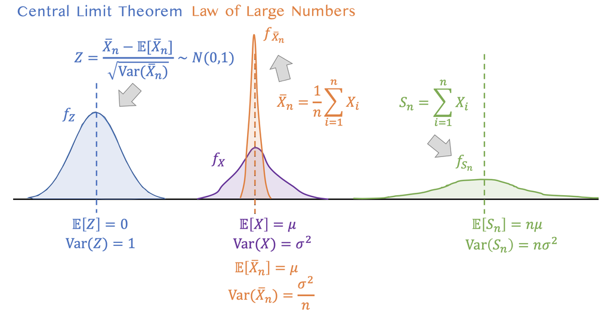

## References

Further details or more topics can be seen in the following textbooks:

- Kevin Murphy. **Machine Learning: A Probabilistic Perspective**, MIT Press 2012. (Chapter 2)
- Marc Deisenroth, Aldo Faisal, and Cheng Soon Ong. **Mathematics for Machine Learning**, Cambridge University Press, 2020. (Chapters 2, 4, 5, 6)
- Sheldon Ross. **A First Course in Probability**. Pearson, 9th Edition, 2014. (Chapters 1-8)

Note: these textbooks have publicly available free e-copies online!

## Appendix

### Proof of SLLN

Suppose that the mean $\mu$ of $X_i$ is equal to 0 and $\mathbb{E}[X_i^4] = K < \infty$. Let $S_n = \sum_{i=1}^n X_i$. Let's consider

\begin{align*} \mathbb{E}[S_n^4] = & \ \mathbb{E}\Bigg[\Big(\sum_{i=1}^n X_i\Big) \Big(\sum_{i=1}^n X_i\Big) \Big(\sum_{i=1}^n X_i\Big) \Big(\sum_{i=1}^n X_i\Big) \Bigg]. \end{align*}

Expanding the right-hand side of the above equation, we can have the following terms:

$$ X_i^4, \hspace{10pt} X_i^3 X_j, \hspace{10pt} X_i^2 X_j^2, \hspace{10pt} X_i^2 X_j X_k, \hspace{10pt} X_i X_j X_k X_l, $$

where $i, j, k, l$ are different indexes. As $X_i$ has mean 0, we then have \begin{align*} \mathbb{E}[X_i^3 X_j] = & \ \mathbb{E}[X_i^3] \mathbb{E}[X_j] = 0, \\ \mathbb{E}[X_i^2 X_j X_k] = & \ \mathbb{E}[X_i^2] \mathbb{E}[X_j] \mathbb{E}[X_k] = 0, \\ \mathbb{E}[X_i X_j X_k X_l] = & \ \mathbb{E}[X_i] \mathbb{E}[X_j] \mathbb{E}[X_k] \mathbb{E}[X_l] = 0. \end{align*}

Thus, we only need to consider the expectation of the terms $X_i^4$ and $X_i^2 X_j^2$. Then \begin{align*} \mathbb{E}[S^4] = & \ n \mathbb{E}[X_i^4] + {4 \choose 2} {n \choose 2} \mathbb{E}[X_i^2] \mathbb{E}[X_j^2] \\ = & \ n K + 3 n (n-1) \mathbb{E}[X_i^2] \mathbb{E}[X_j^2]. \end{align*}

Since we know $Var(X^2_i) = \mathbb{E}[X_i^4] - \mathbb{E}^2[X_i^2] \geq 0$, so $\mathbb{E}^2[X_i^2] \leq \mathbb{E}[X_i^4] = K$. Then we have

$$\mathbb{E}[S^4] \leq n K + 3 n (n-1) K.$$

This gives $$\mathbb{E}\bigg[\Big(\frac{S}{n}\Big)^4\bigg] = \frac{\mathbb{E}[S^4]}{n^4} \leq \frac{K}{n^3} + \frac{3 K}{n^2},$$ then $$\mathbb{E}\bigg[\sum_{n=1}^{\infty} \Big(\frac{S}{n}\Big)^4\bigg] = \sum_{n=1}^{\infty} \mathbb{E}\bigg[\Big(\frac{S}{n}\Big)^4\bigg] < \infty.$$

The convergence of a series implies that its $n$th term goes to 0 as $n \rightarrow \infty$. Therefore, we have $\lim_{n \rightarrow \infty} (S_n/n)^4 = 0$. That is $S_n / n \rightarrow 0$ as $n \rightarrow \infty$. When $\mu$ is not equal to 0, we can create $S_n = \sum_{i=1}^n (X_i - \mu)$ and can obtain the following equation

$$ \lim_{n \rightarrow \infty} \frac{1}{n} \sum_{i=1}^n (X_i - \mu) = 0 \hspace{5pt} \Leftrightarrow \hspace{5pt} \mathbb{P}\Bigg(\lim_{n \rightarrow \infty} \frac{X_1+X_2+\cdots+X_n}{n} = \mu \Bigg) = 1. $$

### Proof of CLT

Let $Z_n = \frac{\bar{X} - \mathbb{E}[\bar{X}]}{\sqrt{\textrm{Var}(\bar{X})}} = \frac{\bar{X} - \mu}{\sigma/\sqrt{n}}$, where $\mathbb{E}[\bar{X} ] = \mu$ and $\mbox{Var}(\bar{X}) = \sigma^2/n$. Then the moment generating function of $Z_n$ is

\begin{align*} m_{Z_n}(t) = & \ \mathbb{E}[e^{t Z_n}] \\ = & \ \mathbb{E}\Bigg[ \exp\bigg\{ t \frac{\bar{X} - \mu}{\sigma/\sqrt{n}} \bigg\} \Bigg] \\ = & \ \mathbb{E}\Bigg[ \exp\bigg\{ \frac{t}{n} \sum_{i=1}^{n} \frac{X_i - \mu}{\sigma/\sqrt{n}} \bigg\} \Bigg] \\ = & \ \mathbb{E}\Bigg[ \exp\bigg\{ \sum_{i=1}^{n} \frac{t}{n} \frac{X_i - \mu}{\sigma/\sqrt{n}} \bigg\} \Bigg] \\ = & \ \prod_{i=1}^{n} \mathbb{E}\Bigg[ \exp\bigg\{ \frac{t}{\sqrt{n}} Y_i \bigg\} \Bigg] && Y_i := \frac{X_i - \mu}{\sigma}\\ = & \ \prod_{i=1}^{n} m_{Y_i}\Big(\frac{t}{\sqrt{n}}\Big) = \Bigg[m_{Y}\Big(\frac{t}{\sqrt{n}}\Big) \Bigg]^n && Y_i \textrm{ are i.i.d.} \end{align*}